# **Student Grade Data**

Martin Dieck Iza - A00827610

Prof. Jobish Vallikavungal Devassia

Visualización de datos para la toma de decisiones - IN2039 - Grupo 6

## Información de los datos

Los datos fueron generados a partir de 395 estudiantes de dos escuelas portuguesas. Incluye información del colegio, calificaciones, datos demográficos, entre otros, y ésta fue recolectada mediante cuestionarios y otras fuentes de información directas.

**Enlace de internet:** https://www.kaggle.com/dipam7/student-grade-prediction

**Referencia:** P. Cortez and A. Silva. Using Data Mining to Predict Secondary School Student Performance. In A. Brito and J. Teixeira Eds., Proceedings of 5th FUture BUsiness TEChnology Conference (FUBUTEC 2008) pp. 5-12, Porto, Portugal, April, 2008, EUROSIS, ISBN 978-9077381-39-7. Available at: http://www3.dsi.uminho.pt/pcortez/student.pdf

[figure not shown]

### Descripción de los datos

Los datos tienen 33 columnas o variables:

- **school** - student's school (binary: 'GP' - Gabriel Pereira or 'MS' - Mousinho da Silveira)
- **sex** - student's sex (binary: 'F' - female or 'M' - male)
- **age** - student's age (numeric: from 15 to 22)
- **address** - student's home address type (binary: 'U' - urban or 'R' - rural)
- **famsize** - family size (binary: 'LE3' - less or equal to 3 or 'GT3' - greater than 3)
- **Pstatus** - parent's cohabitation status (binary: 'T' - living together or 'A' - apart)
- **Medu** - mother's education (numeric: 0 - none, 1 - primary education (4th grade), 2 – 5th to 9th grade, 3 – secondary education or 4 – higher education)
- **Fedu** - father's education (numeric: 0 - none, 1 - primary education (4th grade), 2 – 5th to 9th grade, 3 – secondary education or 4 – higher education)
- **Mjob** - mother's job (nominal: 'teacher', 'health' care related, civil 'services' (e.g. administrative or police), 'at_home' or 'other')
- **Fjob** - father's job (nominal: 'teacher', 'health' care related, civil 'services' (e.g. administrative or police), 'at_home' or 'other')
- **reason** - reason to choose this school (nominal: close to 'home', school 'reputation', 'course' preference or 'other')
- **guardian** - student's guardian (nominal: 'mother', 'father' or 'other')
- **traveltime** - home to school travel time (numeric: 1 - <15 min., 2 - 15 to 30 min., 3 - 30 min. to 1 hour, or 4 - >1 hour)
- **studytime** - weekly study time (numeric: 1 - <2 hours, 2 - 2 to 5 hours, 3 - 5 to 10 hours, or 4 - >10 hours)
- **failures** - number of past class failures (numeric: n if 1<=n<3, else 4)
- **schoolsup** - extra educational support (binary: yes or no)
- **famsup** - family educational support (binary: yes or no)
- **paid** - extra paid classes within the course subject (Math or Portuguese) (binary: yes or no)
- **activities** - extra-curricular activities (binary: yes or no)
- **nursery** - attended nursery school (binary: yes or no)
- **higher** - wants to take higher education (binary: yes or no)
- **internet** - Internet access at home (binary: yes or no)
- **romantic** - with a romantic relationship (binary: yes or no)
- **famrel** - quality of family relationships (numeric: from 1 - very bad to 5 - excellent)
- **freetime** - free time after school (numeric: from 1 - very low to 5 - very high)
- **goout** - going out with friends (numeric: from 1 - very low to 5 - very high)
- **Dalc** - workday alcohol consumption (numeric: from 1 - very low to 5 - very high)
- **Walc** - weekend alcohol consumption (numeric: from 1 - very low to 5 - very high)
- **health** - current health status (numeric: from 1 - very bad to 5 - very good)
- **absences** - number of school absences (numeric: from 0 to 93)
- **G1** - first period grade (numeric: from 0 to 20)
- **G2** - second period grade (numeric: from 0 to 20)
- **G3** - final grade (numeric: from 0 to 20, **output target**)

Se puede observar que cada identificador tiene su significado claro y bien explicado y, por ende, no se necesita realizar una investigación adicional.

### Variables de Interés

De las 33 variables, se seleccionaron las siguientes 15 variables de interés:

- **school** - student's school (binary: 'GP' - Gabriel Pereira or 'MS' - Mousinho da Silveira) - *categorica*
- **sex** - student's sex (binary: 'F' - female or 'M' - male) - *categorica*
- **age** - student's age (numeric: from 15 to 22) - *categorica*
- **address** - student's home address type (binary: 'U' - urban or 'R' - rural) - *categorica*
- **famsize** - family size (binary: 'LE3' - less or equal to 3 or 'GT3' - greater than 3) - *categorica*
- **Pstatus** - parent's cohabitation status (binary: 'T' - living together or 'A' - apart) - *categorica*
- **traveltime** - home to school travel time (numeric: 1 - <15 min., 2 - 15 to 30 min., 3 - 30 min. to 1 hour, or 4 - >1 hour) - *categorica*
- **internet** - Internet access at home (binary: yes or no) - *categorica*
- **romantic** - with a romantic relationship (binary: yes or no) - *categorica*
- **famrel** - quality of family relationships (numeric: from 1 - very bad to 5 - excellent) - *categorica*
- **freetime** - free time after school (numeric: from 1 - very low to 5 - very high) - *categorica*
- **goout** - going out with friends (numeric: from 1 - very low to 5 - very high) - *categorica*
- **Dalc** - workday alcohol consumption (numeric: from 1 - very low to 5 - very high) - *categorica*
- **Walc** - weekend alcohol consumption (numeric: from 1 - very low to 5 - very high) - *categorica*
- **absences** - number of school absences (numeric: from 0 to 93) - *numerica*

Y las siguientes variables de resultado o variables dependientes:

- **G1** - first period grade (numeric: from 0 to 20)
- **G2** - second period grade (numeric: from 0 to 20)
- **G3** - final grade (numeric: from 0 to 20, **output target**)

## Análisis de Datos

### Instalación de módulos

```python
pip install pandas
```

[output not shown]

```python
pip install numpy
```

```python
pip install matplotlib
```

[output not shown]

```python
pip install seaborn
```

[output not shown]

```python
pip install statsmodels
```

[output not shown]

```python
pip install sklearn
```

[output not shown]

```python
pip install plotly
```

[output not shown]

```python
import pandas as pd
import numpy as np
import matplotlib.pyplot as plt
import seaborn as sns
import statsmodels.api as sm
from sklearn import linear_model
import plotly.express as px
```

### Selección de Base de Datos y Limpieza

```python
%ls datasets
```

```
adult.csv                  census.csv     nhanes_2015_2016.csv
airline_data.csv           coches.csv     pokemon.csv
antropometria00.csv        cwurData.csv   reg_data.csv
antropometria-dataset.csv  data.csv       sample_pivot.csv
Book3.csv                  headbrain.csv  StudentGradeData.csv
BreastCancerData.csv       mic2.xlsx      tips.csv
Canada.xlsx                mic.xlsx       weight-height.csv
Cartwheeldata.csv          movies.csv
```

```python
df = pd.read_csv('datasets/StudentGradeData.csv')
df = df[df.G3 != 0]
df.head()
```

|  | school | sex | age | address | famsize | Pstatus | Medu | Fedu | Mjob | Fjob | ... | famrel | freetime | goout | Dalc | Walc | health | absences | G1 | G2 | G3 |
| --- | --- | --- | --- | --- | --- | --- | --- | --- | --- | --- | --- | --- | --- | --- | --- | --- | --- | --- | --- | --- | --- |
| 0 | GP | F | 18 | U | GT3 | A | 4 | 4 | at_home | teacher | ... | 4 | 3 | 4 | 1 | 1 | 3 | 6 | 5 | 6 | 6 |
| 1 | GP | F | 17 | U | GT3 | T | 1 | 1 | at_home | other | ... | 5 | 3 | 3 | 1 | 1 | 3 | 4 | 5 | 5 | 6 |
| 2 | GP | F | 15 | U | LE3 | T | 1 | 1 | at_home | other | ... | 4 | 3 | 2 | 2 | 3 | 3 | 10 | 7 | 8 | 10 |
| 3 | GP | F | 15 | U | GT3 | T | 4 | 2 | health | services | ... | 3 | 2 | 2 | 1 | 1 | 5 | 2 | 15 | 14 | 15 |
| 4 | GP | F | 16 | U | GT3 | T | 3 | 3 | other | other | ... | 4 | 3 | 2 | 1 | 2 | 5 | 4 | 6 | 10 | 10 |

5 rows × 33 columns

```python
df.describe()
```

|  | age | Medu | Fedu | traveltime | studytime | failures | famrel | freetime | goout | Dalc | Walc | health | absences | G1 | G2 | G3 |
| --- | --- | --- | --- | --- | --- | --- | --- | --- | --- | --- | --- | --- | --- | --- | --- | --- |
| count | 357.000000 | 357.000000 | 357.000000 | 357.000000 | 357.000000 | 357.000000 | 357.000000 | 357.000000 | 357.000000 | 357.000000 | 357.000000 | 357.000000 | 357.000000 | 357.000000 | 357.000000 | 357.000000 |
| mean | 16.655462 | 2.795518 | 2.546218 | 1.431373 | 2.042017 | 0.271709 | 3.955182 | 3.246499 | 3.098039 | 1.495798 | 2.330532 | 3.549020 | 6.316527 | 11.268908 | 11.358543 | 11.523810 |
| std | 1.268262 | 1.093999 | 1.084217 | 0.686075 | 0.831895 | 0.671750 | 0.885721 | 1.011601 | 1.090779 | 0.919886 | 1.294974 | 1.402638 | 8.187623 | 3.240450 | 3.147188 | 3.227797 |
| min | 15.000000 | 0.000000 | 0.000000 | 1.000000 | 1.000000 | 0.000000 | 1.000000 | 1.000000 | 1.000000 | 1.000000 | 1.000000 | 1.000000 | 0.000000 | 3.000000 | 5.000000 | 4.000000 |
| 25% | 16.000000 | 2.000000 | 2.000000 | 1.000000 | 1.000000 | 0.000000 | 4.000000 | 3.000000 | 2.000000 | 1.000000 | 1.000000 | 3.000000 | 2.000000 | 9.000000 | 9.000000 | 9.000000 |
| 50% | 17.000000 | 3.000000 | 3.000000 | 1.000000 | 2.000000 | 0.000000 | 4.000000 | 3.000000 | 3.000000 | 1.000000 | 2.000000 | 4.000000 | 4.000000 | 11.000000 | 11.000000 | 11.000000 |
| 75% | 18.000000 | 4.000000 | 3.000000 | 2.000000 | 2.000000 | 0.000000 | 5.000000 | 4.000000 | 4.000000 | 2.000000 | 3.000000 | 5.000000 | 8.000000 | 14.000000 | 14.000000 | 14.000000 |
| max | 22.000000 | 4.000000 | 4.000000 | 4.000000 | 4.000000 | 3.000000 | 5.000000 | 5.000000 | 5.000000 | 5.000000 | 5.000000 | 5.000000 | 75.000000 | 19.000000 | 19.000000 | 20.000000 |

```python
df.corr()
```

|  | age | Medu | Fedu | traveltime | studytime | failures | famrel | freetime | goout | Dalc | Walc | health | absences | G1 | G2 | G3 |
| --- | --- | --- | --- | --- | --- | --- | --- | --- | --- | --- | --- | --- | --- | --- | --- | --- |
| age | 1.000000 | -0.139999 | -0.138532 | 0.106723 | 0.000447 | 0.271748 | 0.066234 | 0.002889 | 0.128041 | 0.142015 | 0.120844 | -0.049694 | 0.215578 | -0.030706 | -0.158273 | -0.140372 |
| Medu | -0.139999 | 1.000000 | 0.608327 | -0.177805 | 0.055764 | -0.214681 | -0.006585 | 0.017753 | 0.078049 | 0.006122 | -0.049314 | -0.043790 | 0.075924 | 0.172444 | 0.203288 | 0.190308 |
| Fedu | -0.138532 | 0.608327 | 1.000000 | -0.185481 | -0.028631 | -0.262197 | -0.009537 | -0.023222 | 0.042474 | -0.018816 | -0.018914 | 0.009127 | 0.008948 | 0.162752 | 0.178706 | 0.158811 |
| traveltime | 0.106723 | -0.177805 | -0.185481 | 1.000000 | -0.095827 | 0.128950 | -0.023566 | -0.007936 | 0.037167 | 0.154209 | 0.139424 | 0.001316 | 0.004628 | -0.086438 | -0.109559 | -0.099785 |
| studytime | 0.000447 | 0.055764 | -0.028631 | -0.095827 | 1.000000 | -0.131072 | 0.052122 | -0.152533 | -0.047891 | -0.199821 | -0.247601 | -0.072786 | -0.074541 | 0.140638 | 0.119759 | 0.126728 |
| failures | 0.271748 | -0.214681 | -0.262197 | 0.128950 | -0.131072 | 1.000000 | -0.007802 | 0.103712 | 0.128388 | 0.167774 | 0.174172 | 0.046940 | 0.148261 | -0.302071 | -0.301316 | -0.293831 |
| famrel | 0.066234 | -0.006585 | -0.009537 | -0.023566 | 0.052122 | -0.007802 | 1.000000 | 0.134631 | 0.030728 | -0.079527 | -0.126642 | 0.108042 | -0.058076 | 0.010083 | -0.005304 | 0.037711 |
| freetime | 0.002889 | 0.017753 | -0.023222 | -0.007936 | -0.152533 | 0.103712 | 0.134631 | 1.000000 | 0.283519 | 0.209400 | 0.132759 | 0.086485 | -0.070492 | 0.005429 | -0.015486 | -0.021589 |
| goout | 0.128041 | 0.078049 | 0.042474 | 0.037167 | -0.047891 | 0.128388 | 0.030728 | 0.283519 | 1.000000 | 0.281761 | 0.444320 | -0.009576 | 0.056590 | -0.150527 | -0.155100 | -0.177383 |
| Dalc | 0.142015 | 0.006122 | -0.018816 | 0.154209 | -0.199821 | 0.167774 | -0.079527 | 0.209400 | 0.281761 | 1.000000 | 0.644920 | 0.088875 | 0.104791 | -0.128721 | -0.127554 | -0.140690 |
| Walc | 0.120844 | -0.049314 | -0.018914 | 0.139424 | -0.247601 | 0.174172 | -0.126642 | 0.132759 | 0.444320 | 0.644920 | 1.000000 | 0.111680 | 0.123100 | -0.176541 | -0.176656 | -0.190054 |
| health | -0.049694 | -0.043790 | 0.009127 | 0.001316 | -0.072786 | 0.046940 | 0.108042 | 0.086485 | -0.009576 | 0.088875 | 0.111680 | 1.000000 | -0.029116 | -0.072126 | -0.059990 | -0.081691 |
| absences | 0.215578 | 0.075924 | 0.008948 | 0.004628 | -0.074541 | 0.148261 | -0.058076 | -0.070492 | 0.056590 | 0.104791 | 0.123100 | -0.029116 | 1.000000 | -0.120313 | -0.199546 | -0.213129 |
| G1 | -0.030706 | 0.172444 | 0.162752 | -0.086438 | 0.140638 | -0.302071 | 0.010083 | 0.005429 | -0.150527 | -0.128721 | -0.176541 | -0.072126 | -0.120313 | 1.000000 | 0.901940 | 0.891805 |
| G2 | -0.158273 | 0.203288 | 0.178706 | -0.109559 | 0.119759 | -0.301316 | -0.005304 | -0.015486 | -0.155100 | -0.127554 | -0.176656 | -0.059990 | -0.199546 | 0.901940 | 1.000000 | 0.965583 |
| G3 | -0.140372 | 0.190308 | 0.158811 | -0.099785 | 0.126728 | -0.293831 | 0.037711 | -0.021589 | -0.177383 | -0.140690 | -0.190054 | -0.081691 | -0.213129 | 0.891805 | 0.965583 | 1.000000 |

### Pregunta de investigación 1: ¿Qué escuela tiene mejores calificaciones en promedio?

```python
my_pivot = pd.pivot_table(df,
                        index = 'school',
                        values = ['G1','G2','G3'],
                        aggfunc = 'mean',#'mean','sum','median']
                        margins = True
                         )
my_pivot
```

| school | G1 | G2 | G3 |
| --- | --- | --- | --- |
| GP | 11.295238 | 11.450794 | 11.622222 |
| MS | 11.071429 | 10.666667 | 10.785714 |
| All | 11.268908 | 11.358543 | 11.523810 |

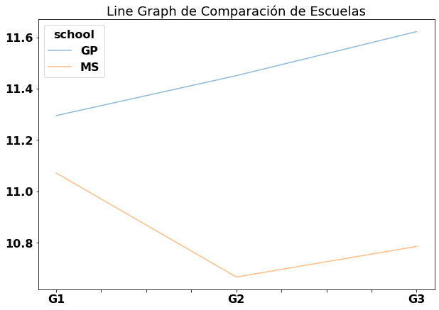

```python
font = {'weight' : 'bold',
        'size'   : 16}

plt.rc('font', **font)
my_pivot.loc[['GP','MS'],['G1','G2','G3']].transpose().plot(kind = 'line',alpha = 0.5, figsize = (10,7))
plt.title('Line Graph de Comparación de Escuelas', fontsize = 18)
plt.show()
```

### Pregunta de investigación 2: ¿Cómo se dividen los travel times y cómo afectan estos en la calificación final?

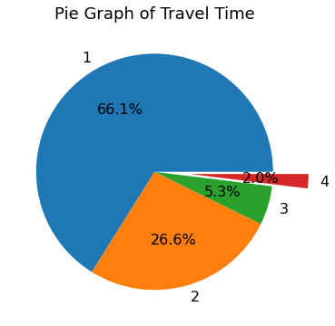

```python
labels = df['traveltime']
df['traveltime'].value_counts().plot(kind='pie', explode = [0,0,0,0.3],figsize = (15,6),autopct='%1.1f%%',  textprops={'fontsize': 16})
plt.title('Pie Graph of Travel Time',fontsize=18)
plt.ylabel("")
plt.show()
```

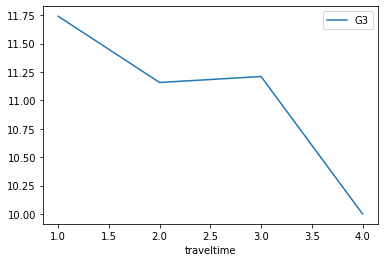

```python
my_pivot = pd.pivot_table(df,
                        index = 'traveltime',
                        values = 'G3',
                        aggfunc = 'mean',#'mean','sum','median']
                         )
my_pivot.plot()
```

```python
modelB = sm.OLS.from_formula('G3~ traveltime',data=df)
resultB = modelB.fit()
resultB.summary()
```

OLS Regression Results

| Dep. Variable: | G3 | R-squared: | 0.010 |
| --- | --- | --- | --- |
| Model: | OLS | Adj. R-squared: | 0.007 |
| Method: | Least Squares | F-statistic: | 3.570 |
| Date: | Thu, 02 Dec 2021 | Prob (F-statistic): | 0.0596 |
| Time: | 13:14:39 | Log-Likelihood: | -922.61 |
| No. Observations: | 357 | AIC: | 1849. |
| Df Residuals: | 355 | BIC: | 1857. |
| Df Model: | 1 |  |  |
| Covariance Type: | nonrobust |  |  |

|  | coef | std err | t | P>\|t\| | [0.025 | 0.975] |
| --- | --- | --- | --- | --- | --- | --- |
| Intercept | 12.1958 | 0.394 | 30.933 | 0.000 | 11.420 | 12.971 |
| traveltime | -0.4695 | 0.248 | -1.890 | 0.060 | -0.958 | 0.019 |

| Omnibus: | 4.772 | Durbin-Watson: | 2.050 |
| --- | --- | --- | --- |
| Prob(Omnibus): | 0.092 | Jarque-Bera (JB): | 4.079 |
| Skew: | 0.178 | Prob(JB): | 0.130 |
| Kurtosis: | 2.615 | Cond. No. | 4.93 |

Notes:  
[1] Standard Errors assume that the covariance matrix of the errors is correctly specified.